# Assignment_#4_Response_Jack_Tan

JACKTANSNAKE

2021/2/11

```r
library(tidyverse)
library(survival)
library(survminer)
HIV = read.csv( "https://www.macalester.edu/~addona/HIV.csv")
Leaders = read.csv( "https://www.macalester.edu/~addona/Leaders.csv")
```

1. One goal of recent research is to explore the efficacy of triple-drug combinations of antiretroviral therapy for the treatment of HIV patients. Due to limitations on potency and the emergence of drug resistance seen with the use of currently available anti-retroviral agents in monotherapy and two-drug regimens, triple-combination regimens could represent a promising approach to maximize anti-viral activity, maintain long-term efficacy, and reduce incidence of drug resistance. Investigators performed a randomized study comparing AZT+zalcitabine to AZT+zalcitabine+saquinavir. HIV.csv has data on time from administration of treatment (in days) until the CD4 count dropped to a prespecified level, along with drug and status indicators, for 34 patients.
1. Is there enough evidence to say that there is a difference in the distribution of the times at which patient’s CD4 reaches the prespecified level for the two treatments? State the hypotheses, test statistic, p-value, and your conclusion.

```r
survdiff(Surv(Time, Status) ~ Drug, data = HIV)
```

```
## Call:
## survdiff(formula = Surv(Time, Status) ~ Drug, data = HIV)
##
##             N Observed Expected (O-E)^2/E (O-E)^2/V
## Drug=NoSaq 17       14     10.5     1.140      2.05
## Drug=Saq   17       13     16.5     0.729      2.05
##
##  Chisq= 2  on 1 degrees of freedom, p= 0.2
```

$H_0$: $S_{Drug = NoSaq}(t) = S_{Drug = Saq}(t)$ for all t.

$H_a$: $S_{Drug = NoSaq}(t) \neq S_{Drug = Saq}(t)$ for some t.

test statistic:

using the Mantel-Cox:

```r
1.140 + 0.729
```

```
## [1] 1.869
```

p-value：

```r
1 - pchisq(1.869, df = 1)
```

```
## [1] 0.1715897
```

Since the p-value is greater than 0.05, there is no significant evidence that there is a difference in the survival of the times at which patient’s CD4 reaches the prespecified level for the two treatments.

2. Find a point and interval estimate of the hazard ratio for the two treatments. Which treatment group is at a higher risk of having their CD4 count drop to the prespecified level?

HR point estimate:

```r
(14/10.5)/(13/16.5)
```

```
## [1] 1.692308
```

HR 95% CI:

```r
# Left endpoint:
1.692308*exp(-1.96*sqrt(1/10.5 + 1/16.5))
```

```
## [1] 0.7806269
```

```r
# Right endpoint:
1.692308*exp(1.96*sqrt(1/10.5 + 1/16.5))
```

```
## [1] 3.668726
```

The group without Saq treatment is at higher risk of having their CD4 count drop to the prespecified level. However, the 95% CI does include 1, which means that we do not have statistically significant evidence to say that.

3. Is the conclusion of the test in (a) consistent with the result in (b)? Briefly explain.

Yes, since the 95% CI for the HR encompasses 1, we do not have statistically significant evidence that there is a difference in the distribution of the times at which patient’s CD4 reaches the prespecified level for the two treatments.

2. Leaders.csv contains data on 472 leaders of countries. For each leader, the following variables were recorded in 1987:

`Years`: Number of years in power (leaders in power for < 1 year were coded as 0)

`Lost`: How leader lost power: 0=still in power in 1987, 1=constitutional exit, 2=death by natural causes, 3=non-constitutional exit

`Manner`: How leader reached power: 0=constitutionally, 1=not constitutionally

`Start`: Year of entry into power (only spells that began in 1960 or later were included)

`Military`: Leader’s background: 1=military, 0=civilian

`Age`: Leader’s age, in years, at time of entry into power

`Conflict`: Level of ethnic conflict: 1=medium/high, 0=low

`LogInc`: Natural log of GNP per capita (dollar equivalent) in 1973

`Growth`: Average annual rate of per capita GNP growth between 1965-1983

`Population`: Population in millions (year not indicated)

`Land`: Area in thousands of square kilometers

`Literacy`: Percent literate (year not indicated)

`Region`: 0=Middle East, 1=Africa, 2=Asia, 3=Latin America (Australia, Europe, and North America was omitted from this data)

1. First, create a status variable: `Leaders$Status = as.numeric(Leaders$Lost > 0)` Graph the Kaplan-Meier curve for the Years variable, specifying conf.type=‘plain’. If you use the base package plot function, you will notice something a little strange at x=0. This is because there are times coded as 0; no need to worry about this (if you like, there is a survfit parameter that can force the curve to start at y=1).

```r
Leaders$Status = as.numeric(Leaders$Lost > 0)
```

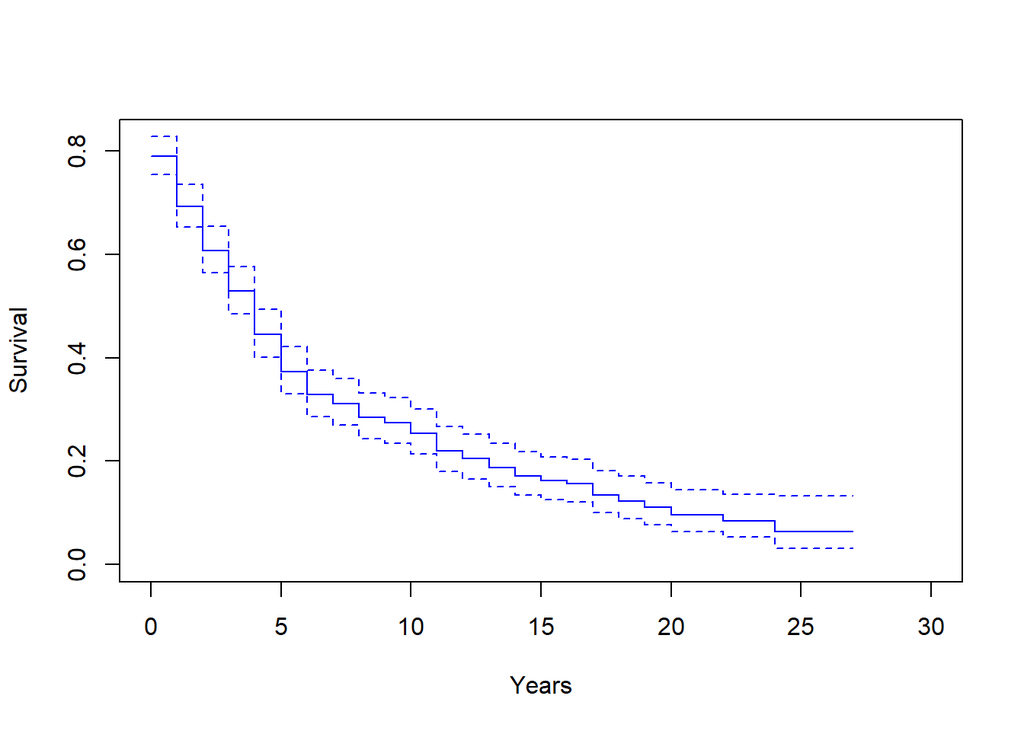

```r
KM <- survfit(Surv(Years, Status) ~ 1 , data = Leaders)
plot(KM, conf.type = "plain", col = "blue", xlab="Years", ylab="Survival", xlim = c(0, 30))
```

2. Graph Kaplan-Meier curves of Years, stratified by the Manner in which the leader reached power. Based on the graph (without C.I.’s, otherwise it is too difficult to read), do you think there is enough evidence to say that the distributions are not identical? Briefly explain.

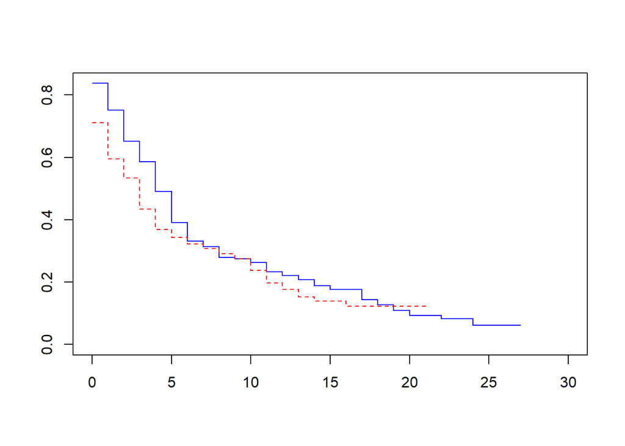

```r
KM <- survfit(Surv(Years, Status) ~ Manner , data = Leaders)
plot(KM, conf.int = FALSE, lty=1:2, col = c("blue", "red"), xlim = c(0,30))
```

3. Now, carry out a formal test of the question in (b).

```r
survdiff(Surv(Years, Status) ~ Manner, data = Leaders)
```

```
## Call:
## survdiff(formula = Surv(Years, Status) ~ Manner, data = Leaders)
##
##            N Observed Expected (O-E)^2/E (O-E)^2/V
## Manner=0 295      223      237     0.879       3.1
## Manner=1 177      134      120     1.746       3.1
##
##  Chisq= 3.1  on 1 degrees of freedom, p= 0.08
```

$H_0$: $S_{Manner = 0}(t) = S_{Manner = 1}(t)$ for all t.

$H_a$: $S_{Manner = 0}(t) \neq S_{Manner = 1}(t)$ for some t.

test statistics:

```r
0.879 + 1.746
```

```
## [1] 2.625
```

p-value:

```r
1 - pchisq(2.625, df = 1)
```

```
## [1] 0.1051925
```

Since the p-value is larger than 0.05, there is no statistically significant evidence that the two survival are not identical.

4. Illustrate that a comparison of the median years in power might show a different conclusion from the one obtained in (c). Why is this not contradictory?

```r
summary(KM)
```

```
## Call: survfit(formula = Surv(Years, Status) ~ Manner, data = Leaders)
##
##                 Manner=0
##  time n.risk n.event survival std.err lower 95% CI upper 95% CI
##     0    295      48   0.8373  0.0215       0.7962        0.880
##     1    244      25   0.7515  0.0252       0.7037        0.803
##     2    212      28   0.6522  0.0280       0.5996        0.710
##     3    177      18   0.5859  0.0292       0.5314        0.646
##     4    153      25   0.4902  0.0301       0.4347        0.553
##     5    123      25   0.3905  0.0298       0.3362        0.454
##     6     93      14   0.3318  0.0292       0.2792        0.394
##     7     74       4   0.3138  0.0290       0.2619        0.376
##     8     64       7   0.2795  0.0285       0.2288        0.341
##     9     53       1   0.2742  0.0285       0.2237        0.336
##    10     48       2   0.2628  0.0284       0.2126        0.325
```

[output cut: 30 more lines]

Median years in power for `Manner` = 0: 4, [4, 5]

Median years in power for `Manner` = 1: 3, [2, 4]

5. Give an example of a scenario where the medians might be very similar, but the survival distributions very different (i.e., describe what the graph of the survival curves could look like, or make a graph in R to help).

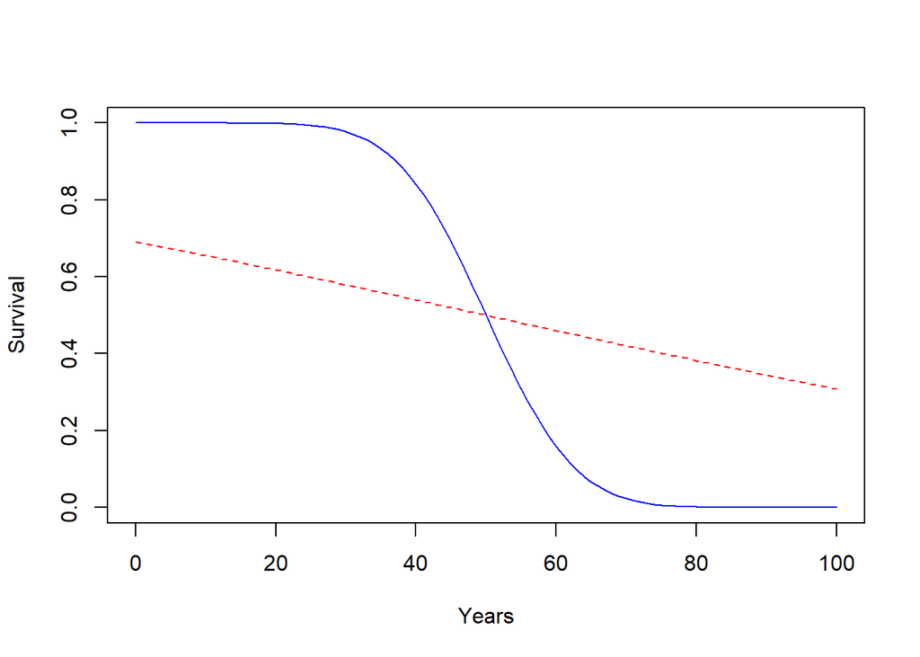

```r
curve(1 - pnorm(x, 50, 10), from = 0, to = 100, ylim=c(0, 1), ylab="Survival", xlab="Years", col = "blue")
curve(1 - pnorm(x, 50, 100), add=TRUE, lty=2, col = "red")
```

6. Perform a Mantel-Cox log-rank test of Years by Region.

```r
survdiff(Surv(Years, Status) ~ Region, data = Leaders)
```

```
## Call:
## survdiff(formula = Surv(Years, Status) ~ Region, data = Leaders)
##
##            N Observed Expected (O-E)^2/E (O-E)^2/V
## Region=0  65       47     55.5     1.311     1.813
## Region=1 134       91    122.0     7.874    14.229
## Region=2  99       72     76.7     0.291     0.432
## Region=3 174      147    102.8    19.051    33.026
##
##  Chisq= 35.3  on 3 degrees of freedom, p= 1e-07
```

test statistics:

```r
1.311 + 7.874 + 0.291 + 19.051
```

```
## [1] 28.527
```

p-value:

```r
1 - pchisq(28.527, df = 3)
```

```
## [1] 2.815157e-06
```

Since the p-value is smaller than 0.05, we have enough evidence to say that the survival curvesfor different regions are not identical.

7. Which of the regions are driving your conclusion in (f)? Explain how you can tell.

`Region` = 3. Since in chi-square the larger the parameter, the smaller the p-value, `Region` = 3 has the largest $\frac{(O-E)^2}{E}$, it contributes the most to the small p-value and our conclusion.

8. Create a categorical Literacy variable with 5 levels (0-20, 20-40, 40-60, 60-80, 80-100) by typing: `Leaders$LitCat = cut( Leaders$Literacy , c(0,20,40,60,80,100) )` Confirm with a log-rank test that LitCat is significantly related to the duration of leaders. Even though the log-rank test does not technically provide this, what is the general direction you see in the relationship between literacy and duration.

```r
Leaders$LitCat = cut(Leaders$Literacy, c(0,20,40,60,80,100))
```

```r
survdiff(Surv(Years, Status) ~ LitCat, data = Leaders)
```

```
## Call:
## survdiff(formula = Surv(Years, Status) ~ LitCat, data = Leaders)
##
##                   N Observed Expected (O-E)^2/E (O-E)^2/V
## LitCat=(0,20]    71       49     63.2     3.191     4.543
## LitCat=(20,40]   69       50     54.1     0.316     0.435
## LitCat=(40,60]   67       44     59.1     3.864     5.412
## LitCat=(60,80]  129      105     86.2     4.113     6.374
## LitCat=(80,100] 136      109     94.4     2.266     3.636
##
##  Chisq= 16.3  on 4 degrees of freedom, p= 0.003
```

test statistics:

```r
3.191 + 0.316 + 3.864 + 4.113 + 2.266
```

```
## [1] 13.75
```

p-value:

```r
1 - pchisq(13.75, df = 4)
```

```
## [1] 0.008137219
```

Since p-value is smaller than 0.05, we have enough evidence to say that the survival are different amount to `LitCat`.

1. Does `LitCat` maintain its significance in the presence of Manner? Check by performing a stratified log-rank test. Does `LitCat` maintain its significance in the presence of Region? Check by performing a stratified log-rank test. Make a table of LitCat by Region: table( `Leaders$Region`, `Leaders$LitCat`) This table gives an indication of the extent to which Region acts as a confounding variable in the Years by LitCat relationship. Briefly explain.

`Manner`:

```r
survdiff(Surv(Years, Status) ~ LitCat + strata(Manner), data = Leaders)
```

```
## Call:
## survdiff(formula = Surv(Years, Status) ~ LitCat + strata(Manner),
##     data = Leaders)
##
##                   N Observed Expected (O-E)^2/E (O-E)^2/V
## LitCat=(0,20]    71       49     64.7      3.79     5.662
## LitCat=(20,40]   69       50     54.8      0.42     0.591
## LitCat=(40,60]   67       44     59.4      4.00     5.733
## LitCat=(60,80]  129      105     85.9      4.27     6.792
## LitCat=(80,100] 136      109     92.3      3.04     4.965
##
##  Chisq= 19.6  on 4 degrees of freedom, p= 6e-04
```

test statistics:

```r
3.79 + 0.42 + 4 + 4.27 + 3.04
```

```
## [1] 15.52
```

p-value:

```r
1 - pchisq(15.52, df = 4)
```

```
## [1] 0.00373576
```

`Region`:

```r
survdiff(Surv(Years, Status) ~ LitCat + strata(Region), data = Leaders)
```

```
## Call:
## survdiff(formula = Surv(Years, Status) ~ LitCat + strata(Region),
##     data = Leaders)
##
##                   N Observed Expected (O-E)^2/E (O-E)^2/V
## LitCat=(0,20]    71       49     49.1  5.79e-05  9.67e-05
## LitCat=(20,40]   69       50     45.8  3.91e-01  5.63e-01
## LitCat=(40,60]   67       44     53.1  1.54e+00  2.28e+00
## LitCat=(60,80]  129      105     90.2  2.43e+00  4.12e+00
## LitCat=(80,100] 136      109    118.9  8.28e-01  2.38e+00
##
##  Chisq= 6.6  on 4 degrees of freedom, p= 0.2
```

test statistics:

```r
5.79e-05 + 3.91e-01 + 1.54e+00+ 2.43e+00 + 8.28e-01
```

```
## [1] 5.189058
```

p-value:

```r
1 - pchisq(5.189058, df = 4)
```

```
## [1] 0.2684432
```

```r
table(Leaders$Region, Leaders$LitCat)
```

```
##
##     (0,20] (20,40] (40,60] (60,80] (80,100]
##   0     10      10      22      23        0
##   1     54      37      21      22        0
##   2      7      20      10      19       43
##   3      0       2      14      65       93
```

LitCat maintains significance in the prescene of `Manner`, but does not maintain significance in the prescene of `Region`.

10. Why did we have to create LitCat in order to explore the relationship between Years and Literacy via a log-rank test?

This is because a log-rank test is used for comparing survival of different groups. Originally, `Literacy` is a numerical variable and thus would generate a large amount of groups. Now by turning it into a categorical variable, we only have 5 groups.

11. Fit a Weibull accelerated failure time model of Years by Literacy. Note: Times of exactly 0 are not accepted by survreg, so add a tiny amount to Years by typing: `m = survreg(Surv(Years+0.001 , Status) ∼ Literacy , dist = ‘weibull’ , data=Leaders)`. Does the direction of the relationship agree with that found using LitCat? Is the relationship between Literacy and Years significant? State the p-value.

```r
m = survreg(Surv(Years+0.001 , Status) ~ Literacy , dist = "weibull", data=Leaders)
summary(m)
```

```
##
## Call:
## survreg(formula = Surv(Years + 0.001, Status) ~ Literacy, data = Leaders,
##     dist = "weibull")
##                Value Std. Error     z       p
## (Intercept)  2.52126    0.33849  7.45 9.4e-14
## Literacy    -0.01380    0.00498 -2.77  0.0056
## Log(scale)   0.95802    0.04776 20.06 < 2e-16
##
## Scale= 2.61
##
## Weibull distribution
## Loglik(model)= -712.8   Loglik(intercept only)= -716.7
##  Chisq= 7.86 on 1 degrees of freedom, p= 0.0051
## Number of Newton-Raphson Iterations: 6
## n= 472
```

12. What does the model in (k) predict for the mean leadership spell for a nation with 70% literacy? 80% literacy? Consider the ratio of these two predictions for the mean: how can we obtain this ratio using the coefficients in the model?

```r
S70 = function(x) 1 - pweibull(x , 1/2.61, exp(2.52126 - 0.01380 * 70))
integrate( S70 , 0 , Inf )
```

```
## 17.80636 with absolute error < 0.0017
```

```r
S80 = function(x) 1 - pweibull(x , 1/2.61, exp(2.52126 - 0.01380 * 80))
integrate( S80 , 0 , Inf )
```

```
## 15.5111 with absolute error < 0.0019
```

```r
15.5111/17.80636
```

```
## [1] 0.8710989
```

```r
exp(-0.01380*10)
```

```
## [1] 0.8710987
```

13. Does Literacy maintain its significance once we control for Region? Note: Since Region is coded as 0 to 3, make sure that it is treated as a categorical variable, by using factor(Region), that is, type: `m = survreg( Surv(Years+0.001 , Status) ∼ Literacy + factor(Region) , dist = ‘weibull’ , data=Leaders )`

```r
m = survreg(Surv(Years+0.001, Status) ~ Literacy + factor(Region), dist = "weibull", data=Leaders)
summary(m)
```

```
##
## Call:
## survreg(formula = Surv(Years + 0.001, Status) ~ Literacy + factor(Region),
##     data = Leaders, dist = "weibull")
##                     Value Std. Error     z       p
## (Intercept)      2.104983   0.491599  4.28 1.9e-05
## Literacy        -0.000405   0.006463 -0.06   0.950
## factor(Region)1  0.257156   0.469617  0.55   0.584
## factor(Region)2 -0.243890   0.493238 -0.49   0.621
## factor(Region)3 -1.150246   0.477055 -2.41   0.016
## Log(scale)       0.944090   0.047868 19.72 < 2e-16
##
## Scale= 2.57
##
## Weibull distribution
## Loglik(model)= -706.9   Loglik(intercept only)= -716.7
##  Chisq= 19.61 on 4 degrees of freedom, p= 6e-04
## Number of Newton-Raphson Iterations: 6
## n= 472
```

since the p-value is larger than 0.05, `Literacy` does not maintain its significance.

3. Consider the following small survival data set broken into two groups:

Group 1: 2, 6+, 7, 12, 16+

Group 2: 7, 11, 15+, 18, 25+

1. How many 2-by-2 tables will be required to carry out the log-rank test?

5

2. Make the first two of these tables.

```r
table_f <- life_table <- data.frame(`Interval(0,2]` = c("Group 1", "Group 2", "Total"), Failed = c(1, 0, 1), `Didn't Fail` = c(4, 5, 9), Total = c(5, 5, 10))
table_f
```

```
##   Interval.0.2. Failed Didn.t.Fail Total
## 1       Group 1      1           4     5
## 2       Group 2      0           5     5
## 3         Total      1           9    10
```

```r
table_s <- life_table <- data.frame(`Interval(2,7]` = c("Group 1", "Group 2", "Total"), Failed = c(1, 1, 2), `Didn't Fail` = c(2, 4, 6), Total = c(3, 5, 8))
table_s
```

```
##   Interval.2.7. Failed Didn.t.Fail Total
## 1       Group 1      1           2     3
## 2       Group 2      1           4     5
## 3         Total      2           6     8
```

3. Find the expected number of failures in each group for the second table from (b).

$E_1 = \frac{3*2}{8} = 0.75$

$E_2 = \frac{5*2}{8} = 1.25$

4. Answer the following True/False questions:
1. True/False: The log-rank test provides a pointwise comparison of two survival curves.

False

2. True/False: If the confidence interval for a hazard ratio does not encompass 0, there is enough evidence to conclude that the risk of failure in the two groups being compared is different.

False

3. True/False: The log-rank test can only check for the significance of a categorical explanatory variable.

True

4. True/False: Accelerated failure time models are often built on a log-scale to ensure that time is positive.

True

5. True/False: The Normal model is built on a log-scale.

False

6. True/False: In a Weibull accelerated failure time model, covariates affect the scale parameter, but not the shape parameter.

True

8. True/False: The natural log of each coefficient in an accelerated failure time model is interpreted as a “time ratio”, e.g., as a multiplier of mean survival time.

False

1. True/False: An advantage of using a Log-Normal model is that its hazard function can be non-monotonic.

True